# Capstone Project

Data Science Specialisation

Lisa van der Heijden

27-4-2020

## Introduction

- This Slidify presentation is part of the Data Science Specialisation Capstone project on Coursera
- The aim of this project is to develop a web application that predicts the next word in a phrase
- This presentation aims to explain the use of the web application as well as the mechanism of prediction

## The web application

- The assingment can be found at (https://www.coursera.org/learn/data-science-project)
- The goal is to use Natural Language Processing (NLP) to predict the next word of a phrase
- The web application can be found at (https://littlemeadow1994.shinyapps.io/Prediction_app/)
- The input of the web application is a word or a phrase (sequence of multiple words)
- The ouput is the word that is predicted to be next in the phrase

## How to use the web application

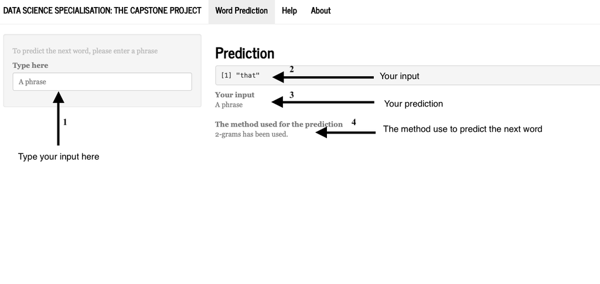

1. The user enters a word or a phrase (sequence of words) at arrow 1.
2. The prediction model will predict the next word in the phrase and displays it at arrow 2.
3. At arrow 3 the input of the user is visualised.
4. At arrow 4 the method of prediction is visualised.

## Mechanisms of prediction

**First**, the input of the user is compared with three datasets:

1. The quadgram.RData set containing four word phrases and their frequency of occurence.
2. The trigram.RData set containing three word phrases and their frequency of occurence
3. The bigram.RData set containing two word phrases and their frequency of occurence

**Continuining** , the prediction tries to find the input in one of these datasets.

**Finally**, the word with the highest frequency is returned.

*Example* If the input is *‘the end of’* the prediction will be *‘the’*

```
##   unigram bigram trigram quadgram freq
## 1     the    end      of      the  146
## 2  thanks    for     the   follow  137
## 3      at    the     end       of  126
## 4     for    the   first     time  122
## 5     the   rest      of      the  122
## 6      is    one      of      the   88
```